# Contents

- 0 Cscs
- 1. Introduction and Data Preprocessing
  - 1.1 Problem Statement
  - 1.2 Packages
  - 1.3 Read or Import
  - 1.4 Data Summary variables definition
  - 1.5 Data Preparation
- 1 Prepare Data for Consumption
  - 1.1 Import Libraries
    - 1.1.1 Load Data Modelling Libraries
  - 1.2 Meet and Greet Data
    - 1.1.1 The 4 Cs of Data Cleaning: Correcting, Completing, Creating, and Converting
- 2 Feature Engineering
  - 2.1 Within its variable
    - 2.1.1 Dependent/Target Variables
      - 2.1.1.1 Qualitative/Categorical Variables
        - 2.1.1.1.1 ['Transported']
    - 2.1.2 Independent/Response Variables
      - 2.1.2.1 Quantitative/Numerical Variables
        - 2.1.2.1.1 ['Age']
        - 2.1.2.1.2 ['RoomService', 'FoodCourt', 'ShoppingMall', 'Spa', 'VRDeck']
        - 2.1.2.1.3 Recap
      - 2.1.2.2 Qualitative/Categorical Variables
        - 2.1.2.2.1 ['HomePlanet', 'CryoSleep', 'Destination', 'VIP']
        - 2.1.2.2.5 Recap
      - 2.1.2.3 Descriptive Variables
        - 2.1.2.3.1 ['PassengerId']
        - 2.1.2.3.2 ['Cabin']
        - 2.1.2.3.3 ['Name']
        - 2.1.2.3.4 Recap
      - 2.1.2.4 Recap

  -2.2 Inter variables

# 1 Prepare Data for Consumption

## 1.1 Import Libraries

```python
"""
Author: Rifqi Azhari
Date: 03/05/2024
"""

# This Python 3 environment comes with many helpful analytics libraries installed
# It is defined by the kaggle/python docker image: https://github.com/kaggle/docker-python

#load packages
import sys #access to system parameters https://docs.python.org/3/library/sys.html
print("Python version: {}". format(sys.version))

import pandas as pd #collection of functions for data processing and analysis modeled after R dataframes with SQL like features
print("pandas version: {}". format(pd.__version__))

import matplotlib #collection of functions for scientific and publication-ready visualization
print("matplotlib version: {}". format(matplotlib.__version__))

import numpy as np #foundational package for scientific computing
print("NumPy version: {}". format(np.__version__))

import scipy as sp #collection of functions for scientific computing and advance mathematics
print("SciPy version: {}". format(sp.__version__))

import IPython
from IPython import display #pretty printing of dataframes in Jupyter notebook
print("IPython version: {}". format(IPython.__version__))

import sklearn #collection of machine learning algorithms
print("scikit-learn version: {}". format(sklearn.__version__))

#misc libraries
import random
import time


#ignore warnings
import warnings
warnings.filterwarnings('ignore')
print('-'*25)
```

```
Python version: 3.9.12 (main, Apr  4 2022, 05:22:27) [MSC v.1916 64 bit (AMD64)]
pandas version: 1.4.2
matplotlib version: 3.5.1
NumPy version: 1.21.5
SciPy version: 1.7.3
IPython version: 8.2.0
scikit-learn version: 1.0.2
-------------------------
```

### 1.1.1 Load Data Modelling Libraries

```python
#Common Model Algorithms
from sklearn import svm, tree, linear_model, neighbors, naive_bayes, ensemble, discriminant_analysis, gaussian_process

#Common Model Helpers
from sklearn.preprocessing import OneHotEncoder, LabelEncoder
from sklearn import feature_selection
from sklearn import model_selection
from sklearn import metrics
from sklearn.pipeline import Pipeline
from sklearn.compose import ColumnTransformer

#Visualization
import matplotlib as mpl
import matplotlib.pyplot as plt
import matplotlib.pylab as pylab
import seaborn as sns
from pandas.plotting import scatter_matrix

#Configure Visualization Defaults
#%matplotlib inline = show plots in Jupyter Notebook browser
%matplotlib inline
mpl.style.use('ggplot')
sns.set_style('white')
pylab.rcParams['figure.figsize'] = 12,8
```

## 1.2 Data Summary

```
1. PassengerId - A unique Id for each passenger. Each Id takes the form gggg_pp where gggg indicates a group the passenger is travelling with and pp is their number within the group. People in a group are often family members, but not always.
2. HomePlanet - The planet the passenger departed from, typically their planet of permanent residence.
3. CryoSleep - Indicates whether the passenger elected to be put into suspended animation for the duration of the voyage. Passengers in cryosleep are confined to their cabins.
4. Cabin - The cabin number where the passenger is staying. Takes the form deck/num/side, where side can be either P for Port or S for Starboard.
5. Destination - The planet the passenger will be debarking to.
6. Age - The age of the passenger.
7. VIP - Whether the passenger has paid for special VIP service during the voyage.
8. RoomService, FoodCourt, ShoppingMall, Spa, VRDeck - Amount the passenger has billed at each of the Spaceship Titanic's many luxury amenities.
9. Name - The first and last names of the passenger.
10. Transported - Whether the passenger was transported to another dimension. This is the target, the column you are trying to predict.
```

```python
data_raw = pd.read_csv('train.csv')
data_val  = pd.read_csv('test.csv')


# #to play with our data we'll create a copy
# #remember python assignment or equal passes by reference vs values, so we use the copy function: https://stackoverflow.com/questions/46327494/python-pandas-dataframe-copydeep-false-vs-copydeep-true-vs
data1 = data_raw.copy(deep = True)

# #however passing by reference is convenient, because we can clean both datasets at once
data_cleaner = [data1, data_val]

#preview data
print (data_raw.info()) #https://pandas.pydata.org/pandas-docs/stable/generated/pandas.DataFrame.info.html
#data_raw.head() #https://pandas.pydata.org/pandas-docs/stable/generated/pandas.DataFrame.head.html
#data_raw.tail() #https://pandas.pydata.org/pandas-docs/stable/generated/pandas.DataFrame.tail.html
data_raw.sample(10) #https://pandas.pydata.org/pandas-docs/stable/generated/pandas.DataFrame.sample.html
```

```
<class 'pandas.core.frame.DataFrame'>
RangeIndex: 8693 entries, 0 to 8692
Data columns (total 14 columns):
 #   Column        Non-Null Count  Dtype
---  ------        --------------  -----
 0   PassengerId   8693 non-null   object
 1   HomePlanet    8492 non-null   object
 2   CryoSleep     8476 non-null   object
 3   Cabin         8494 non-null   object
 4   Destination   8511 non-null   object
 5   Age           8514 non-null   float64
 6   VIP           8490 non-null   object
 7   RoomService   8512 non-null   float64
 8   FoodCourt     8510 non-null   float64
 9   ShoppingMall  8485 non-null   float64
 10  Spa           8510 non-null   float64
 11  VRDeck        8505 non-null   float64
 12  Name          8493 non-null   object
 13  Transported   8693 non-null   bool
dtypes: bool(1), float64(6), object(7)
memory usage: 891.5+ KB
None
```

|  | PassengerId | HomePlanet | CryoSleep | Cabin | Destination | Age | VIP | RoomService | FoodCourt | ShoppingMall | Spa | VRDeck | Name | Transported |
| --- | --- | --- | --- | --- | --- | --- | --- | --- | --- | --- | --- | --- | --- | --- |
| 5792 | 6137_01 | Earth | False | G/994/S | TRAPPIST-1e | 2.0 | False | 0.0 | 0.0 | 0.0 | 0.0 | 0.0 | Camily Serry | True |
| 3886 | 4169_02 | Europa | False | D/140/P | TRAPPIST-1e | 41.0 | False | 0.0 | 1562.0 | 0.0 | 2.0 | 16.0 | Acruxon Susent | True |
| 4945 | 5272_01 | Mars | True | F/1076/P | TRAPPIST-1e | 20.0 | False | 0.0 | 0.0 | 0.0 | 0.0 | 0.0 | Push Winie | True |
| 4427 | 4706_01 | Earth | True | G/762/P | TRAPPIST-1e | 30.0 | False | 0.0 | 0.0 | 0.0 | 0.0 | 0.0 | Andra Medington | False |
| 3401 | 3658_02 | Earth | False | E/245/S | TRAPPIST-1e | 24.0 | False | 3.0 | 2053.0 | 335.0 | 0.0 | 4.0 | Vin Daughttley | True |
| 6729 | 7097_01 | Europa | False | A/75/P | 55 Cancri e | 27.0 | False | 0.0 | 44.0 | 4761.0 | 5.0 | 41.0 | Altanin Dedometeel | True |
| 3684 | 3959_03 | Earth | True | G/646/P | 55 Cancri e | 0.0 | False | 0.0 | 0.0 | 0.0 | 0.0 | 0.0 | Maya Sullones | True |
| 7342 | 7856_01 | Earth | False | F/1503/S | TRAPPIST-1e | 34.0 | NaN | 0.0 | 0.0 | 0.0 | 156.0 | 620.0 | Darrie Contrevins | False |
| 4127 | 4403_01 | Earth | False | F/831/S | TRAPPIST-1e | 55.0 | False | 134.0 | 935.0 | 0.0 | 6.0 | 394.0 | Lina Peter | False |
| 3928 | 4194_01 | Mars | True | F/862/P | 55 Cancri e | 34.0 | False | 0.0 | 0.0 | 0.0 | 0.0 | 0.0 | Oaters Kité | True |

```python
# Duplicates
print(f'Duplicates in train set: {data_raw.duplicated().sum()}, ({np.round(100*data_raw.duplicated().sum()/len(data_raw),1)}%)')
print('')
print(f'Duplicates in test set: {data_val.duplicated().sum()}, ({np.round(100*data_val.duplicated().sum()/len(data_val),1)}%)')
```

```
Duplicates in train set: 0, (0.0%)

Duplicates in test set: 0, (0.0%)
```

### 1.2.1 Feature Engineering

```python
print('Train columns with null values:\n', data1.isnull().sum())
print("-"*10)

print('Test/Validation columns with null values:\n', data_val.isnull().sum())
print("-"*10)

data_raw.describe(include = 'all')
```

```
Train columns with null values:
 PassengerId       0
HomePlanet      201
CryoSleep       217
Cabin           199
Destination     182
Age             179
VIP             203
RoomService     181
FoodCourt       183
ShoppingMall    208
Spa             183
VRDeck          188
Name            200
Transported       0
dtype: int64
----------
Test/Validation columns with null values:
 PassengerId       0
HomePlanet       87
CryoSleep        93
Cabin           100
Destination      92
Age              91
VIP              93
RoomService      82
FoodCourt       106
ShoppingMall     98
Spa             101
VRDeck           80
Name             94
dtype: int64
----------
```

|  | PassengerId | HomePlanet | CryoSleep | Cabin | Destination | Age | VIP | RoomService | FoodCourt | ShoppingMall | Spa | VRDeck | Name | Transported |
| --- | --- | --- | --- | --- | --- | --- | --- | --- | --- | --- | --- | --- | --- | --- |
| count | 8693 | 8492 | 8476 | 8494 | 8511 | 8514.000000 | 8490 | 8512.000000 | 8510.000000 | 8485.000000 | 8510.000000 | 8505.000000 | 8493 | 8693 |
| unique | 8693 | 3 | 2 | 6560 | 3 | NaN | 2 | NaN | NaN | NaN | NaN | NaN | 8473 | 2 |
| top | 0001_01 | Earth | False | G/734/S | TRAPPIST-1e | NaN | False | NaN | NaN | NaN | NaN | NaN | Gollux Reedall | True |
| freq | 1 | 4602 | 5439 | 8 | 5915 | NaN | 8291 | NaN | NaN | NaN | NaN | NaN | 2 | 4378 |
| mean | NaN | NaN | NaN | NaN | NaN | 28.827930 | NaN | 224.687617 | 458.077203 | 173.729169 | 311.138778 | 304.854791 | NaN | NaN |
| std | NaN | NaN | NaN | NaN | NaN | 14.489021 | NaN | 666.717663 | 1611.489240 | 604.696458 | 1136.705535 | 1145.717189 | NaN | NaN |
| min | NaN | NaN | NaN | NaN | NaN | 0.000000 | NaN | 0.000000 | 0.000000 | 0.000000 | 0.000000 | 0.000000 | NaN | NaN |
| 25% | NaN | NaN | NaN | NaN | NaN | 19.000000 | NaN | 0.000000 | 0.000000 | 0.000000 | 0.000000 | 0.000000 | NaN | NaN |
| 50% | NaN | NaN | NaN | NaN | NaN | 27.000000 | NaN | 0.000000 | 0.000000 | 0.000000 | 0.000000 | 0.000000 | NaN | NaN |
| 75% | NaN | NaN | NaN | NaN | NaN | 38.000000 | NaN | 47.000000 | 76.000000 | 27.000000 | 59.000000 | 46.000000 | NaN | NaN |
| max | NaN | NaN | NaN | NaN | NaN | 79.000000 | NaN | 14327.000000 | 29813.000000 | 23492.000000 | 22408.000000 | 24133.000000 | NaN | NaN |

```python
data_raw.nunique()
```

```
PassengerId     8693
HomePlanet         3
CryoSleep          2
Cabin           6560
Destination        3
Age               80
VIP                2
RoomService     1273
FoodCourt       1507
ShoppingMall    1115
Spa             1327
VRDeck          1306
Name            8473
Transported        2
dtype: int64
```

```python
data_raw.dtypes
```

```
PassengerId      object
HomePlanet       object
CryoSleep        object
Cabin            object
Destination      object
Age             float64
VIP              object
RoomService     float64
FoodCourt       float64
ShoppingMall    float64
Spa             float64
VRDeck          float64
Name             object
Transported        bool
dtype: object
```

There are 6 continuous features, 4 categorical features (excluding the target) and 3 descriptive/qualitative features.

```python
# Expenditure features
exp_feats=['RoomService', 'FoodCourt', 'ShoppingMall', 'Spa', 'VRDeck']

# Categorical features
cat_feats=['HomePlanet', 'CryoSleep', 'Destination', 'VIP']

# Qualitative features
qual_feats=['PassengerId', 'Cabin' ,'Name']
```

# 2 Clean Data Feature Engineering

# 2 Feature Engineering

```python
#data1 train_data
#data_val val_data

#data_cleaner = [data1, data_val] for cleaning both tables
```

## 2.1 Early filter of missing data

```python
missing_data_train_count = data1.isnull().sum()
missing_data_train_percent = data1.isnull().sum() / len(data1) * 100

missing_data_train = pd.DataFrame({
    'data1 Count': missing_data_train_count,
    'data1 Percent': missing_data_train_percent
})
missing_data_train = missing_data_train[missing_data_train['data1 Count'] > 0]
missing_data_train.sort_values(by='data1 Count', ascending=False, inplace=True)

print(f"There are {missing_data_train.shape[0]} features having missing data in training set.")

###
missing_data_val_count = data_val.isnull().sum()
missing_data_val_percent = data_val.isnull().sum() / len(data_val) * 100

missing_data_val = pd.DataFrame({
    'data_val Count': missing_data_val_count,
    'data_val Percent': missing_data_val_percent
})
missing_data_val = missing_data_val[missing_data_val['data_val Count'] > 0]
missing_data_val.sort_values(by='data_val Count', ascending=False, inplace=True)

print(f"There are {missing_data_val.shape[0]} features having missing data in test set.")

result = pd.concat([missing_data_train, missing_data_val], axis=1)
result
```

```
There are 12 features having missing data in training set.
There are 12 features having missing data in test set.
```

|  | data1 Count | data1 Percent | data_val Count | data_val Percent |
| --- | --- | --- | --- | --- |
| CryoSleep | 217 | 2.496261 | 93 | 2.174421 |
| ShoppingMall | 208 | 2.392730 | 98 | 2.291326 |
| VIP | 203 | 2.335212 | 93 | 2.174421 |
| HomePlanet | 201 | 2.312205 | 87 | 2.034136 |
| Name | 200 | 2.300702 | 94 | 2.197802 |
| Cabin | 199 | 2.289198 | 100 | 2.338087 |
| VRDeck | 188 | 2.162660 | 80 | 1.870470 |
| FoodCourt | 183 | 2.105142 | 106 | 2.478373 |
| Spa | 183 | 2.105142 | 101 | 2.361468 |
| Destination | 182 | 2.093639 | 92 | 2.151040 |
| RoomService | 181 | 2.082135 | 82 | 1.917232 |
| Age | 179 | 2.059128 | 91 | 2.127660 |

There is no variable that has missing value more than 10% of its proportion. We could continue without deleting any variable

## 2.1 Within its variable

### 2.1.1 Dependent/Target Variable

#### 2.1.1.1 Qualitative/Categorical Variables

##### 2.1.1.1.1 ['Transported']

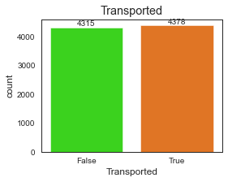

```python
plt.figure(figsize=(4,3))
ax = sns.countplot(x='Transported', data=data1, palette='gist_ncar')
ax.bar_label(ax.containers[0])
plt.title('Transported')
```

### 2.1.2 Independent/Response Variables

#### 2.1.2.1 Quantitative/Numerical Variables

##### 2.1.2.1.1 ['Age']

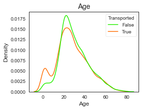

```python
plt.figure(figsize=(4,3))
sns.kdeplot(data=data1, x='Age', hue='Transported', palette='gist_ncar')
title = plt.title("Age")
```

As we can see the distribution has unique pattern, we will discretize this value with custom range adjusted to the pattern shown in the distribution

This variable has unique patter in its distribution, for filling the missing values we need to apply special method, but for now I will just fill the missing values with its mean value. Later I will do the improvement

```python
for dataset in data_cleaner:
    dataset['Age'] = dataset['Age'].fillna(dataset['Age'].mean())
```

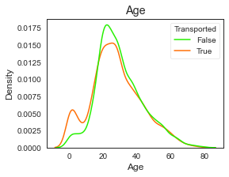

```python
plt.figure(figsize=(4,3))
sns.kdeplot(data=data1, x='Age', hue='Transported', palette='gist_ncar')
title = plt.title("Age")
```

As we can see, the distribution doesnt change that much. Its because the null value only 2 percent of its proportion

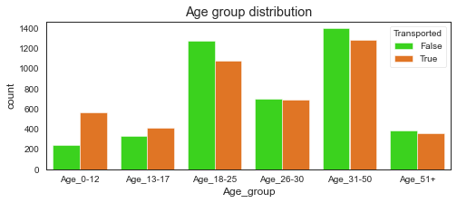

```python
for dataset in data_cleaner:
    dataset['Age_group']=np.nan
    dataset.loc[dataset['Age']<=12,'Age_group']='Age_0-12'
    dataset.loc[(dataset['Age']>12) & (dataset['Age']<18),'Age_group']='Age_13-17'
    dataset.loc[(dataset['Age']>=18) & (dataset['Age']<=25),'Age_group']='Age_18-25'
    dataset.loc[(dataset['Age']>25) & (dataset['Age']<=30),'Age_group']='Age_26-30'
    dataset.loc[(dataset['Age']>30) & (dataset['Age']<=50),'Age_group']='Age_31-50'
    dataset.loc[dataset['Age']>50,'Age_group']='Age_51+'

# Plot distribution of new features
plt.figure(figsize=(8,3))
g=sns.countplot(data=data1, x='Age_group', hue='Transported', order=['Age_0-12','Age_13-17','Age_18-25','Age_26-30','Age_31-50','Age_51+'], palette='gist_ncar')
plt.title('Age group distribution')
```

ADD: ['Age_group']

##### 2.1.2.1.2 ['RoomService', 'FoodCourt', 'ShoppingMall', 'Spa', 'VRDeck']

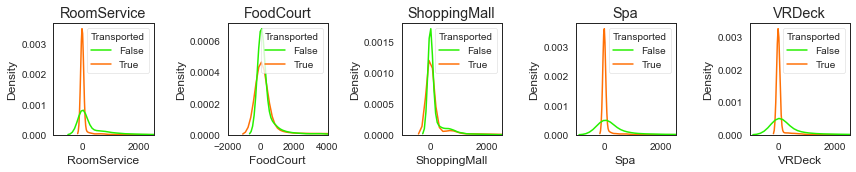

```python
fig=plt.figure(figsize=(12,2.5))
plt.subplot(1,5,1)
sns.kdeplot(data=data1, x='RoomService', hue='Transported', palette='gist_ncar')
title = plt.title("RoomService")
plt.xlim([-1000,2500])

plt.subplot(1,5,2)
sns.kdeplot(data=data1, x='FoodCourt', hue='Transported', palette='gist_ncar')
title = plt.title("FoodCourt")
plt.xlim([-2000,4000])

plt.subplot(1,5,3)
sns.kdeplot(data=data1, x='ShoppingMall', hue='Transported', palette='gist_ncar')
title = plt.title("ShoppingMall")
plt.xlim([-1000,2500])

plt.subplot(1,5,4)
sns.kdeplot(data=data1, x='Spa', hue='Transported', palette='gist_ncar')
title = plt.title("Spa")
plt.xlim([-1000,2500])

plt.subplot(1,5,5)
sns.kdeplot(data=data1, x='VRDeck', hue='Transported', palette='gist_ncar')
title = plt.title("VRDeck")
plt.xlim([-1000,2500])
fig.tight_layout()
```

These 5 variables have same meaning which is a money expenditure. So in the next box, we will add a new variable.

```python
for dataset in data_cleaner:
    dataset['RoomService'] = dataset['RoomService'].fillna(dataset['RoomService'].mean())
    dataset['FoodCourt'] = dataset['FoodCourt'].fillna(dataset['FoodCourt'].mean())
    dataset['ShoppingMall'] = dataset['ShoppingMall'].fillna(dataset['ShoppingMall'].mean())
    dataset['Spa'] = dataset['Spa'].fillna(dataset['Spa'].mean())
    dataset['VRDeck'] = dataset['VRDeck'].fillna(dataset['VRDeck'].mean())
```

```python
# Expenditure features
exp_feats=['RoomService', 'FoodCourt', 'ShoppingMall', 'Spa', 'VRDeck']
```

```
(0.0, 20000.0)
```

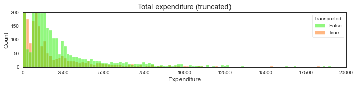

```python
for dataset in data_cleaner:
    dataset['Expenditure']=dataset[exp_feats].sum(axis=1)

# Plot distribution of new features
fig=plt.figure(figsize=(25,2))
plt.subplot(1,2,1)
sns.histplot(data=data1, x='Expenditure', hue='Transported', bins=200, palette='gist_ncar')
plt.title('Total expenditure (truncated)')
plt.ylim([0,200])
plt.xlim([0,20000])
```

From the accumulation we can see that the distribution has a unique pattern. The counts at value equal to 0 is very high. So I will add new binary variable that split the value equal to 0 and not equal to 0

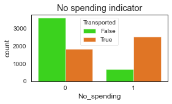

```python
for dataset in data_cleaner:
    dataset['No_spending']=(dataset['Expenditure']==0).astype(int)

# Plot distribution of new features
fig=plt.figure(figsize=(4,2))
sns.countplot(data=data1, x='No_spending', hue='Transported', palette='gist_ncar')
plt.title('No spending indicator')
```

ADD: ['Expenditure', 'No_spending']

```python
missing_data_train_count = data1.isnull().sum()
missing_data_train_percent = data1.isnull().sum() / len(data1) * 100

missing_data_train = pd.DataFrame({
    'data1 Count': missing_data_train_count,
    'data1 Percent': missing_data_train_percent
})
missing_data_train = missing_data_train[missing_data_train['data1 Count'] > 0]
missing_data_train.sort_values(by='data1 Count', ascending=False, inplace=True)

print(f"There are {missing_data_train.shape[0]} features having missing data in training set.")

###
missing_data_val_count = data_val.isnull().sum()
missing_data_val_percent = data_val.isnull().sum() / len(data_val) * 100

missing_data_val = pd.DataFrame({
    'data_val Count': missing_data_val_count,
    'data_val Percent': missing_data_val_percent
})
missing_data_val = missing_data_val[missing_data_val['data_val Count'] > 0]
missing_data_val.sort_values(by='data_val Count', ascending=False, inplace=True)

print(f"There are {missing_data_val.shape[0]} features having missing data in test set.")

result = pd.concat([missing_data_train, missing_data_val], axis=1)
result
```

```
There are 6 features having missing data in training set.
There are 6 features having missing data in test set.
```

|  | data1 Count | data1 Percent | data_val Count | data_val Percent |
| --- | --- | --- | --- | --- |
| CryoSleep | 217 | 2.496261 | 93 | 2.174421 |
| VIP | 203 | 2.335212 | 93 | 2.174421 |
| HomePlanet | 201 | 2.312205 | 87 | 2.034136 |
| Name | 200 | 2.300702 | 94 | 2.197802 |
| Cabin | 199 | 2.289198 | 100 | 2.338087 |
| Destination | 182 | 2.093639 | 92 | 2.151040 |

```python
['RoomService', 'FoodCourt', 'ShoppingMall', 'Spa', 'VRDeck', 'Age'] fill with mean
['HomePlanet', 'CryoSleep', 'Destination', 'VIP', 'Age_group'] fill with mode
['Surname', 'Family_size', 'Cabin_deck', 'Cabin_number', 'Cabin_side']
```

#### 2.1.2.2 Qualitative/Categorical Variables

##### 2.1.2.2.1 ['HomePlanet', 'CryoSleep', 'Destination', 'VIP']

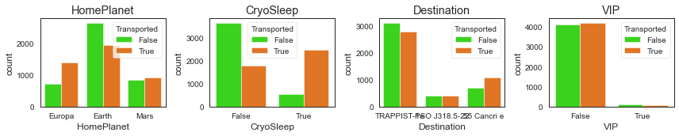

```python
fig=plt.figure(figsize=(12,2.5))
plt.subplot(1,4,1)
sns.countplot(data=data1, x='HomePlanet', hue='Transported', palette='gist_ncar')
title = plt.title("HomePlanet")

plt.subplot(1,4,2)
sns.countplot(data=data1, x='CryoSleep', hue='Transported', palette='gist_ncar')
title = plt.title("CryoSleep")

plt.subplot(1,4,3)
sns.countplot(data=data1, x='Destination', hue='Transported', palette='gist_ncar')
title = plt.title("Destination")

plt.subplot(1,4,4)
sns.countplot(data=data1, x='VIP', hue='Transported', palette='gist_ncar')
title = plt.title("VIP")
fig.tight_layout()
```

```python
for dataset in data_cleaner:
    dataset['HomePlanet'] = dataset['HomePlanet'].fillna(dataset['HomePlanet'].mode()[0])
    dataset['CryoSleep'] = dataset['CryoSleep'].fillna(dataset['CryoSleep'].mode()[0])
    dataset['Destination'] = dataset['Destination'].fillna(dataset['Destination'].mode()[0])
    dataset['VIP'] = dataset['VIP'].fillna(dataset['VIP'].mode()[0])
```

```python
missing_data_train_count = data1.isnull().sum()
missing_data_train_percent = data1.isnull().sum() / len(data1) * 100

missing_data_train = pd.DataFrame({
    'data1 Count': missing_data_train_count,
    'data1 Percent': missing_data_train_percent
})
missing_data_train = missing_data_train[missing_data_train['data1 Count'] > 0]
missing_data_train.sort_values(by='data1 Count', ascending=False, inplace=True)

print(f"There are {missing_data_train.shape[0]} features having missing data in training set.")

###
missing_data_val_count = data_val.isnull().sum()
missing_data_val_percent = data_val.isnull().sum() / len(data_val) * 100

missing_data_val = pd.DataFrame({
    'data_val Count': missing_data_val_count,
    'data_val Percent': missing_data_val_percent
})
missing_data_val = missing_data_val[missing_data_val['data_val Count'] > 0]
missing_data_val.sort_values(by='data_val Count', ascending=False, inplace=True)

print(f"There are {missing_data_val.shape[0]} features having missing data in test set.")

result = pd.concat([missing_data_train, missing_data_val], axis=1)
result
```

```
There are 2 features having missing data in training set.
There are 2 features having missing data in test set.
```

|  | data1 Count | data1 Percent | data_val Count | data_val Percent |
| --- | --- | --- | --- | --- |
| Name | 200 | 2.300702 | 94 | 2.197802 |
| Cabin | 199 | 2.289198 | 100 | 2.338087 |

#### 2.1.2.3 Descriptive Variables

##### 2.1.2.3.1 ['PassengerId']

PassengerID has gggg_pp pattern where:

```
gggg: indicates a group the passenger is travelling with
      people in the group often family (not always)
pp:   is their number within the group
```

```python
data1['PassengerId'].head(3)
```

```
0    0001_01
1    0002_01
2    0003_01
Name: PassengerId, dtype: object
```

I will split the gggg and pp using its delimiter but I will not use the pp variable since its way to specific and wont have any meaningful value in our prediction

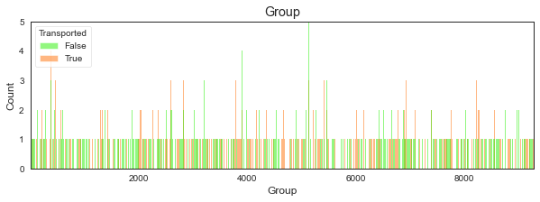

```python
for dataset in data_cleaner:
    dataset['Group'] = dataset['PassengerId'].apply(lambda x: x.split('_')[0]).astype(int)

# Plot distribution of new features
plt.figure(figsize=(10,3))
sns.histplot(data=data1, x='Group', hue='Transported', binwidth=1, palette='gist_ncar')
plt.title('Group')
plt.ylim([0,5])
plt.xlim([1,9280])
fig.tight_layout()
```

['Group'] variable is a categorical ordinal variable, but since it has very high cardinality it will explode when we do one-hot encoding. We will add a new variable instead, we will group 'Group' variable by its count value

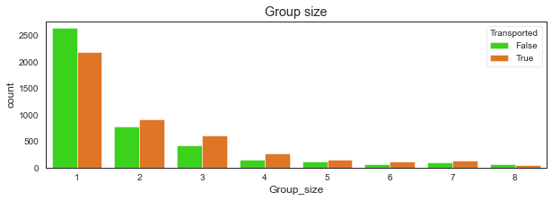

```python
for dataset in data_cleaner:
    dataset['Group_size']= dataset['Group'].map(lambda x: dataset['Group'].value_counts()[x])

# Plot distribution of new features
plt.figure(figsize=(10,3))
sns.countplot(data=data1, x='Group_size', hue='Transported', palette='gist_ncar')
plt.title('Group size')
fig.tight_layout()
```

From ['Group_size'] distribution we can see a unique pattern where the ['Group_size'] == 1 has a very high value. From the case context we can know that value means the passenger traveling alone. From this we can seperate binary between the passengers that travelled alone and with group. We will add a new binary variable called ['Solo'] below

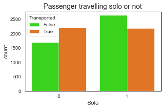

```python
for dataset in data_cleaner:
    dataset['Solo']=(dataset['Group_size']==1).astype(int)

# New feature distribution
plt.figure(figsize=(5,3))
sns.countplot(data=data1, x='Solo', hue='Transported', palette='gist_ncar')
plt.title('Passenger travelling solo or not')
```

ADD: ['Group', 'Group_size', 'Solo'] REMOVE: ['Group']

##### 2.1.2.3.2 ['Cabin']

Cabin is a variable where the passenger is staying. This variable has deck/num/side pattern. We will split this variable using its delimiter

```python
data1['Cabin'].head(3)
```

```
0    B/0/P
1    F/0/S
2    A/0/S
Name: Cabin, dtype: object
```

First we need to check the null value before spliting the variable

```python
print(dataset['Cabin'].isna().sum())
```

```
100
```

Because its a descriptive variable and we havent split the variable yet. We just need to fill the null value with a dummy

```python
for dataset in data_cleaner:
    # Replace NaN's with outliers for now (so we can split feature)
    dataset['Cabin'].fillna('Z/9999/Z', inplace=True)
```

Now we are ready to split the variable

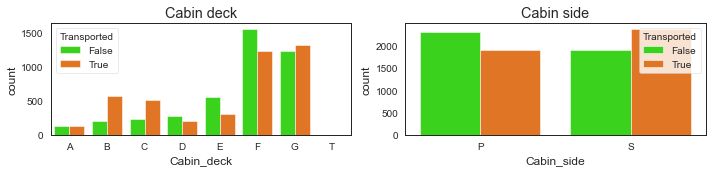

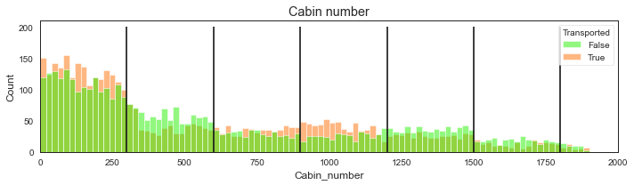

```python
for dataset in data_cleaner:
    # New features
    dataset['Cabin_deck'] = dataset['Cabin'].apply(lambda x: x.split('/')[0])
    dataset['Cabin_number'] = dataset['Cabin'].apply(lambda x: x.split('/')[1]).astype(int)
    dataset['Cabin_side'] = dataset['Cabin'].apply(lambda x: x.split('/')[2])

    # Put Nan's back in (we will fill these later)
    dataset.loc[dataset['Cabin_deck']=='Z', 'Cabin_deck']=np.nan
    dataset.loc[dataset['Cabin_number']==9999, 'Cabin_number']=np.nan
    dataset.loc[dataset['Cabin_side']=='Z', 'Cabin_side']=np.nan

    # Drop Cabin (we don't need it anymore)
    #dataset.drop('Cabin', axis=1, inplace=True)

# Plot distribution of new features
fig=plt.figure(figsize=(10, 2.5))
plt.subplot(1,2,1)
sns.countplot(data=data1, x='Cabin_deck', hue='Transported', order=['A','B','C','D','E','F','G','T'], palette='gist_ncar')
plt.title('Cabin deck')

plt.subplot(1,2,2)
sns.countplot(data=data1, x='Cabin_side', hue='Transported', palette='gist_ncar')
plt.title('Cabin side')
fig.tight_layout()

fig=plt.figure(figsize=(10,3))
sns.histplot(data=data1, x='Cabin_number', hue='Transported',binwidth=20, palette='gist_ncar')
plt.vlines(300, ymin=0, ymax=200, color='black')
plt.vlines(600, ymin=0, ymax=200, color='black')
plt.vlines(900, ymin=0, ymax=200, color='black')
plt.vlines(1200, ymin=0, ymax=200, color='black')
plt.vlines(1500, ymin=0, ymax=200, color='black')
plt.vlines(1800, ymin=0, ymax=200, color='black')
plt.title('Cabin number')
plt.xlim([0,2000])
fig.tight_layout()
```

The ['Cabin_number'] has unique patterns, since it has a very high cardinality, i will discretize into smaller range value

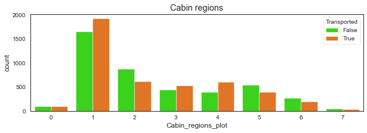

```python
for dataset in data_cleaner:
    # New features - training set
    dataset['Cabin_region1']=(dataset['Cabin_number']<300).astype(int)   # one-hot encoding
    dataset['Cabin_region2']=((dataset['Cabin_number']>=300) & (dataset['Cabin_number']<600)).astype(int)
    dataset['Cabin_region3']=((dataset['Cabin_number']>=600) & (dataset['Cabin_number']<900)).astype(int)
    dataset['Cabin_region4']=((dataset['Cabin_number']>=900) & (dataset['Cabin_number']<1200)).astype(int)
    dataset['Cabin_region5']=((dataset['Cabin_number']>=1200) & (dataset['Cabin_number']<1500)).astype(int)
    dataset['Cabin_region6']=((dataset['Cabin_number']>=1500) & (dataset['Cabin_number']<1800)).astype(int)
    dataset['Cabin_region7']=(dataset['Cabin_number']>=1800).astype(int)

# Plot distribution of new features
plt.figure(figsize=(10,3))
data1['Cabin_regions_plot']=(data1['Cabin_region1']+2*data1['Cabin_region2']+3*data1['Cabin_region3']+4*data1['Cabin_region4']+5*data1['Cabin_region5']+6*data1['Cabin_region6']+7*data1['Cabin_region7']).astype(int)
sns.countplot(data=data1, x='Cabin_regions_plot', hue='Transported', palette='gist_ncar')
plt.title('Cabin regions')
data1.drop('Cabin_regions_plot', axis=1, inplace=True)
```

```python
missing_data_train_count = data1.isnull().sum()
missing_data_train_percent = data1.isnull().sum() / len(data1) * 100

missing_data_train = pd.DataFrame({
    'data1 Count': missing_data_train_count,
    'data1 Percent': missing_data_train_percent
})
missing_data_train = missing_data_train[missing_data_train['data1 Count'] > 0]
missing_data_train.sort_values(by='data1 Count', ascending=False, inplace=True)

print(f"There are {missing_data_train.shape[0]} features having missing data in training set.")

###
missing_data_val_count = data_val.isnull().sum()
missing_data_val_percent = data_val.isnull().sum() / len(data_val) * 100

missing_data_val = pd.DataFrame({
    'data_val Count': missing_data_val_count,
    'data_val Percent': missing_data_val_percent
})
missing_data_val = missing_data_val[missing_data_val['data_val Count'] > 0]
missing_data_val.sort_values(by='data_val Count', ascending=False, inplace=True)

print(f"There are {missing_data_val.shape[0]} features having missing data in test set.")

result = pd.concat([missing_data_train, missing_data_val], axis=1)
result
```

```
There are 4 features having missing data in training set.
There are 4 features having missing data in test set.
```

|  | data1 Count | data1 Percent | data_val Count | data_val Percent |
| --- | --- | --- | --- | --- |
| Name | 200 | 2.300702 | 94 | 2.197802 |
| Cabin_deck | 199 | 2.289198 | 100 | 2.338087 |
| Cabin_number | 199 | 2.289198 | 100 | 2.338087 |
| Cabin_side | 199 | 2.289198 | 100 | 2.338087 |

##### 2.1.2.3.3 ['Name']

```python
data1['Name'].head(3)
```

```
0    Maham Ofracculy
1       Juanna Vines
2      Altark Susent
Name: Name, dtype: object
```

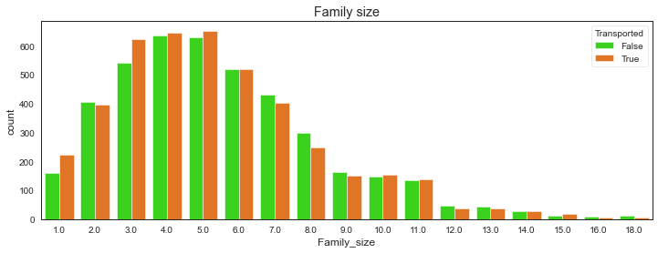

```python
for dataset in data_cleaner:
    # Calculate family size from last name.
    # Replace NaN's with outliers for now (so we can split feature)
    dataset['Name'].fillna('Unknown Unknown', inplace=True)
    # New feature - Surname
    dataset['Surname']=dataset['Name'].str.split().str[-1]
    # New feature - Family size
    dataset['Family_size']=dataset['Surname'].map(lambda x: dataset['Surname'].value_counts()[x])
    # Put Nan's back in (we will fill these later)
    dataset.loc[dataset['Surname']=='Unknown','Surname']=np.nan
    dataset.loc[dataset['Family_size']>100,'Family_size']=np.nan
    # Drop name (we don't need it anymore)
    #dataset.drop('Name', axis=1, inplace=True) $$$$$$$$$$$$$$$$$$$$$$$$$$$$$$$$$$$$$$$$$$$$$$$$

# New feature distribution
plt.figure(figsize=(12,4))
sns.countplot(data=data1, x='Family_size', hue='Transported', palette='gist_ncar')
plt.title('Family size')
```

```python
for dataset in data_cleaner:
    dataset.drop('Name', axis=1, inplace=True)
```

#### 2.1.2.4 Recap

```
['PassengerID'] to ['Group', 'Group_size', 'Solo'].
['Cabin'] to ['Cabin_deck', 'Cabin_number', 'Cabin_side', 'Cabin_region']. drop ['Cabin']
['Name'] to ['Surname', 'Family_size']. drop ['Name']
```

```python
missing_data_train_count = data1.isnull().sum()
missing_data_train_percent = data1.isnull().sum() / len(data1) * 100

missing_data_train = pd.DataFrame({
    'data1 Count': missing_data_train_count,
    'data1 Percent': missing_data_train_percent
})
missing_data_train = missing_data_train[missing_data_train['data1 Count'] > 0]
missing_data_train.sort_values(by='data1 Count', ascending=False, inplace=True)

print(f"There are {missing_data_train.shape[0]} features having missing data in training set.")

###
missing_data_val_count = data_val.isnull().sum()
missing_data_val_percent = data_val.isnull().sum() / len(data_val) * 100

missing_data_val = pd.DataFrame({
    'data_val Count': missing_data_val_count,
    'data_val Percent': missing_data_val_percent
})
missing_data_val = missing_data_val[missing_data_val['data_val Count'] > 0]
missing_data_val.sort_values(by='data_val Count', ascending=False, inplace=True)

print(f"There are {missing_data_val.shape[0]} features having missing data in test set.")

result = pd.concat([missing_data_train, missing_data_val], axis=1)
result
```

```
There are 5 features having missing data in training set.
There are 4 features having missing data in test set.
```

|  | data1 Count | data1 Percent | data_val Count | data_val Percent |
| --- | --- | --- | --- | --- |
| Surname | 200 | 2.300702 | 94.0 | 2.197802 |
| Family_size | 200 | 2.300702 | NaN | NaN |
| Cabin_deck | 199 | 2.289198 | 100.0 | 2.338087 |
| Cabin_number | 199 | 2.289198 | 100.0 | 2.338087 |
| Cabin_side | 199 | 2.289198 | 100.0 | 2.338087 |

## 2.2 Inter variables

```python
for dataset in data_cleaner:
    # Columns with missing values
    na_cols=dataset.columns[dataset.isna().any()].tolist()
    mv=pd.DataFrame(dataset[na_cols].isna().sum(), columns=['Number_missing'])
    mv['Percentage_missing']=np.round(100*mv['Number_missing']/len(dataset),2)
    print(mv, '\n')
```

```
              Number_missing  Percentage_missing
Cabin_deck               199                2.29
Cabin_number             199                2.29
Cabin_side               199                2.29
Surname                  200                2.30
Family_size              200                2.30

              Number_missing  Percentage_missing
Cabin_deck               100                2.34
Cabin_number             100                2.34
Cabin_side               100                2.34
Surname                   94                2.20
```

## 1 Surname

```python
for data in data_cleaner:
    # Joint distribution of Group and Surname
    GSN_gb=data[data['Group_size']>1].groupby(['Group','Surname'])['Surname'].size().unstack().fillna(0)

    # The majority (83%) of groups contain only 1 family. So let's fill missing surnames according to the majority surname in that group.
    # Missing values before
    SN_bef=data['Surname'].isna().sum()

    # Passengers with missing Surname and in a group with known majority Surname
    GSN_index=data[data['Surname'].isna()][(data[data['Surname'].isna()]['Group']).isin(GSN_gb.index)].index

    # Fill corresponding missing values
    data.loc[GSN_index,'Surname']=data.iloc[GSN_index,:]['Group'].map(lambda x: GSN_gb.idxmax(axis=1)[x])

    # Print number of missing values left
    print('#Surname missing values before:',SN_bef)
    print('#Surname missing values after:',data['Surname'].isna().sum())

    # Replace NaN's with outliers (so we can use map)
    data['Surname'].fillna('Unknown', inplace=True)

    # Update family size feature
    data['Family_size']=data['Surname'].map(lambda x: data['Surname'].value_counts()[x])

    # Put NaN's back in place of outliers
    data.loc[data['Surname']=='Unknown','Surname']=np.nan

    # Say unknown surname means no family
    data.loc[data['Family_size']>100,'Family_size']=0
```

```
#Surname missing values before: 200
#Surname missing values after: 104
#Surname missing values before: 94
#Surname missing values after: 51
```

## 2 Cabin side

```python
for data in data_cleaner:
    # Joint distribution of Group and Cabin features
    GCD_gb=data[data['Group_size']>1].groupby(['Group','Cabin_deck'])['Cabin_deck'].size().unstack().fillna(0)
    GCN_gb=data[data['Group_size']>1].groupby(['Group','Cabin_number'])['Cabin_number'].size().unstack().fillna(0)
    GCS_gb=data[data['Group_size']>1].groupby(['Group','Cabin_side'])['Cabin_side'].size().unstack().fillna(0)

    # Everyone in the same group is also on the same cabin side. For cabin deck and cabin number there is also a fairly good (but not perfect) correlation with group.
    # Missing values before
    CS_bef=data['Cabin_side'].isna().sum()

    # Passengers with missing Cabin side and in a group with known Cabin side
    GCS_index=data[data['Cabin_side'].isna()][(data[data['Cabin_side'].isna()]['Group']).isin(GCS_gb.index)].index

    # Fill corresponding missing values
    data.loc[GCS_index,'Cabin_side']=data.iloc[GCS_index,:]['Group'].map(lambda x: GCS_gb.idxmax(axis=1)[x])

    # Print number of missing values left
    print('#Cabin_side missing values before:',CS_bef)
    print('#Cabin_side missing values after:',data['Cabin_side'].isna().sum())
```

```
#Cabin_side missing values before: 199
#Cabin_side missing values after: 99
#Cabin_side missing values before: 100
#Cabin_side missing values after: 63
```

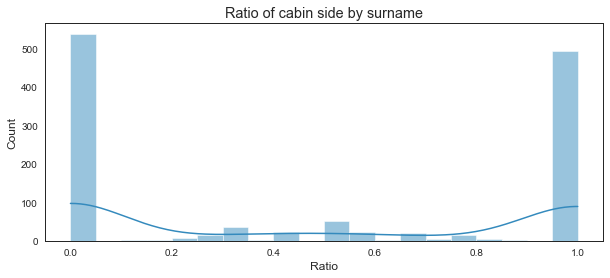

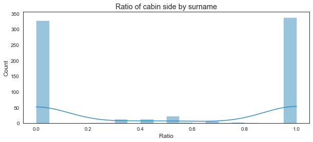

```python
for data in data_cleaner:
    # Joint distribution of Surname and Cabin side
    SCS_gb=data[data['Group_size']>1].groupby(['Surname','Cabin_side'])['Cabin_side'].size().unstack().fillna(0)

    # Ratio of sides
    SCS_gb['Ratio']=SCS_gb['P']/(SCS_gb['P']+SCS_gb['S'])

    # Histogram of ratio
    plt.figure(figsize=(10,4))
    sns.histplot(SCS_gb['Ratio'], kde=True, binwidth=0.05)
    plt.title('Ratio of cabin side by surname')
```

```python
# Print proportion
print('Percentage of families all on the same cabin side:', 100*np.round((SCS_gb['Ratio'].isin([0,1])).sum()/len(SCS_gb),3),'%')

# Another view of the same information
SCS_gb.head()
```

```
Percentage of families all on the same cabin side: 91.0 %
```

| Cabin_side Surname | P | S | Ratio |
| --- | --- | --- | --- |
| Acobsond | 3.0 | 0.0 | 1.0 |
| Aginge | 3.0 | 0.0 | 1.0 |
| Aillyber | 3.0 | 0.0 | 1.0 |
| Aindlylid | 0.0 | 1.0 | 0.0 |
| Airdring | 0.0 | 2.0 | 0.0 |

```python
# Missing values before
CS_bef=data['Cabin_side'].isna().sum()

# Drop ratio column
SCS_gb.drop('Ratio', axis=1, inplace=True)

for data in data_cleaner:
    # Passengers with missing Cabin side and in a family with known Cabin side
    SCS_index=data[data['Cabin_side'].isna()][(data[data['Cabin_side'].isna()]['Surname']).isin(SCS_gb.index)].index

    # Fill corresponding missing values
    data.loc[SCS_index,'Cabin_side']=data.iloc[SCS_index,:]['Surname'].map(lambda x: SCS_gb.idxmax(axis=1)[x])

    # Drop surname (we don't need it anymore)
    data.drop('Surname', axis=1, inplace=True)

    # Print number of missing values left
    print('#Cabin_side missing values before:',CS_bef)
    print('#Cabin_side missing values after:',data['Cabin_side'].isna().sum())
```

```
#Cabin_side missing values before: 63
#Cabin_side missing values after: 74
#Cabin_side missing values before: 63
#Cabin_side missing values after: 45
```

```python
for data in data_cleaner:
    # Value counts
    data['Cabin_side'].value_counts()

    # Missing values before
    CS_bef=data['Cabin_side'].isna().sum()

    # Fill remaining missing values with outlier
    data.loc[data['Cabin_side'].isna(),'Cabin_side']='Z'

    # Print number of missing values left
    print('#Cabin_side missing values before:',CS_bef)
    print('#Cabin_side missing values after:',data['Cabin_side'].isna().sum())
```

```
#Cabin_side missing values before: 74
#Cabin_side missing values after: 0
#Cabin_side missing values before: 45
#Cabin_side missing values after: 0
```

## 3 Cabin_deck

```python
for data in data_cleaner:
    # Missing values before
    CD_bef=data['Cabin_deck'].isna().sum()

    # Passengers with missing Cabin deck and in a group with known majority Cabin deck
    GCD_index=data[data['Cabin_deck'].isna()][(data[data['Cabin_deck'].isna()]['Group']).isin(GCD_gb.index)].index

    # Fill corresponding missing values
    data.loc[GCD_index,'Cabin_deck']=data.iloc[GCD_index,:]['Group'].map(lambda x: GCD_gb.idxmax(axis=1)[x])

    # Print number of missing values left
    print('#Cabin_deck missing values before:',CD_bef)
    print('#Cabin_deck missing values after:',data['Cabin_deck'].isna().sum())
```

```
#Cabin_deck missing values before: 199
#Cabin_deck missing values after: 199
#Cabin_deck missing values before: 100
#Cabin_deck missing values after: 63
```

```python
for data in data_cleaner:
    # Joint distribution
    data.groupby(['HomePlanet','Destination','Solo','Cabin_deck'])['Cabin_deck'].size().unstack().fillna(0)
    '''
    Passengers from Mars are most likely in deck F.
    Passengers from Europa are (more or less) most likely in deck C if travelling solo and deck B otherwise.
    Passengers from Earth are (more or less) most likely in deck G.
    We will fill in missing values according to where the mode appears in these subgroups.
    '''
    # Missing values before
    CD_bef=data['Cabin_deck'].isna().sum()

    # Fill missing values using the mode
    na_rows_CD=data.loc[data['Cabin_deck'].isna(),'Cabin_deck'].index
    data.loc[data['Cabin_deck'].isna(),'Cabin_deck']=data.groupby(['HomePlanet','Destination','Solo'])['Cabin_deck'].transform(lambda x: x.fillna(pd.Series.mode(x)[0]))[na_rows_CD]

    # Print number of missing values left
    print('#Cabin_deck missing values before:',CD_bef)
    print('#Cabin_deck missing values after:',data['Cabin_deck'].isna().sum())
```

```
#Cabin_deck missing values before: 199
#Cabin_deck missing values after: 0
#Cabin_deck missing values before: 63
#Cabin_deck missing values after: 0
```

## 4 Cabin Number

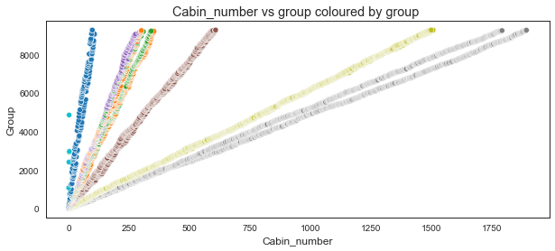

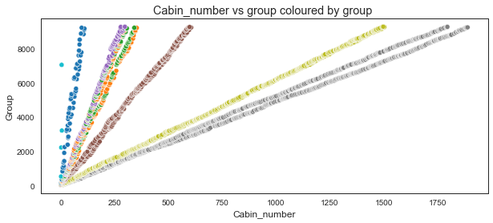

```python
for data in data_cleaner:
    # Scatterplot
    plt.figure(figsize=(10,4))
    sns.scatterplot(x=data['Cabin_number'], y=data['Group'], c=LabelEncoder().fit_transform(data.loc[~data['Cabin_number'].isna(),'Cabin_deck']), cmap='tab10')
    plt.title('Cabin_number vs group coloured by group ')
```

```python
for data in data_cleaner:
    # Missing values before
    CN_bef=data['Cabin_number'].isna().sum()
    print('#Cabin_number missing values before:',CN_bef)
    # Extrapolate linear relationship on a deck by deck basis
    for deck in ['A', 'B', 'C', 'D', 'E', 'F', 'G']:
        # Features and labels
        X_CN=data.loc[~(data['Cabin_number'].isna()) & (data['Cabin_deck']==deck),'Group']
        y_CN=data.loc[~(data['Cabin_number'].isna()) & (data['Cabin_deck']==deck),'Cabin_number']
        X_test_CN=data.loc[(data['Cabin_number'].isna()) & (data['Cabin_deck']==deck),'Group']

        if not X_test_CN.empty:
            # Linear regression
            model_CN=sklearn.linear_model.LinearRegression()
            model_CN.fit(X_CN.values.reshape(-1, 1), y_CN)
            preds_CN=model_CN.predict(X_test_CN.values.reshape(-1, 1))

            # Fill missing values with predictions
            data.loc[(data['Cabin_number'].isna()) & (data['Cabin_deck']==deck),'Cabin_number']=preds_CN.astype(int)

    # Print number of missing values left
    print('#Cabin_number missing values before:',CN_bef)
    print('#Cabin_number missing values after:',data['Cabin_number'].isna().sum())

    # One-hot encode cabin regions
    data['Cabin_region1']=(data['Cabin_number']<300).astype(int)
    data['Cabin_region2']=((data['Cabin_number']>=300) & (data['Cabin_number']<600)).astype(int)
    data['Cabin_region3']=((data['Cabin_number']>=600) & (data['Cabin_number']<900)).astype(int)
    data['Cabin_region4']=((data['Cabin_number']>=900) & (data['Cabin_number']<1200)).astype(int)
    data['Cabin_region5']=((data['Cabin_number']>=1200) & (data['Cabin_number']<1500)).astype(int)
    data['Cabin_region6']=((data['Cabin_number']>=1500) & (data['Cabin_number']<1800)).astype(int)
    data['Cabin_region7']=(data['Cabin_number']>=1800).astype(int)
```

```
#Cabin_number missing values before: 199
#Cabin_number missing values before: 199
#Cabin_number missing values after: 0
#Cabin_number missing values before: 100
#Cabin_number missing values before: 100
#Cabin_number missing values after: 0
```

```python
for dataset in data_cleaner:
    # Columns with missing values
    na_cols=dataset.columns[dataset.isna().any()].tolist()
    mv=pd.DataFrame(dataset[na_cols].isna().sum(), columns=['Number_missing'])
    mv['Percentage_missing']=np.round(100*mv['Number_missing']/len(dataset),2)
    print(mv, '\n')
```

```
Empty DataFrame
Columns: [Number_missing, Percentage_missing]
Index: []

Empty DataFrame
Columns: [Number_missing, Percentage_missing]
Index: []
```

## Drop

```python
data1.info()
```

```
<class 'pandas.core.frame.DataFrame'>
RangeIndex: 8693 entries, 0 to 8692
Data columns (total 30 columns):
 #   Column         Non-Null Count  Dtype
---  ------         --------------  -----
 0   PassengerId    8693 non-null   object
 1   HomePlanet     8693 non-null   object
 2   CryoSleep      8693 non-null   bool
 3   Cabin          8693 non-null   object
 4   Destination    8693 non-null   object
 5   Age            8693 non-null   float64
 6   VIP            8693 non-null   bool
 7   RoomService    8693 non-null   float64
 8   FoodCourt      8693 non-null   float64
 9   ShoppingMall   8693 non-null   float64
```

[output cut: 22 more lines]

```python
for dataset in data_cleaner:
    dataset.drop('Cabin', axis=1, inplace=True)
```

## Convert Formats

```python
data1.info()
```

```
<class 'pandas.core.frame.DataFrame'>
RangeIndex: 8693 entries, 0 to 8692
Data columns (total 29 columns):
 #   Column         Non-Null Count  Dtype
---  ------         --------------  -----
 0   PassengerId    8693 non-null   object
 1   HomePlanet     8693 non-null   object
 2   CryoSleep      8693 non-null   bool
 3   Destination    8693 non-null   object
 4   Age            8693 non-null   float64
 5   VIP            8693 non-null   bool
 6   RoomService    8693 non-null   float64
 7   FoodCourt      8693 non-null   float64
 8   ShoppingMall   8693 non-null   float64
 9   Spa            8693 non-null   float64
```

[output cut: 21 more lines]

```python
data1['HomePlanet'].head(3)
```

```
0    Europa
1     Earth
2    Europa
Name: HomePlanet, dtype: object
```

```python
#CONVERT: convert objects to category using Label Encoder for train and test/validation dataset

#code categorical data
label = LabelEncoder()

for data in data_cleaner:
    data['HomePlanet_Code'] = label.fit_transform(data['HomePlanet'])
    data['CryoSleep_Code'] = label.fit_transform(data['CryoSleep'])
    data['Destination_Code'] = label.fit_transform(data['Destination'])
    data['VIP_Code'] = label.fit_transform(data['VIP'])
    data['Age_group_Code'] = label.fit_transform(data['Age_group'])
    data['Cabin_deck_Code'] = label.fit_transform(data['Cabin_deck'])
    data['Cabin_side_Code'] = label.fit_transform(data['Cabin_side'])
```

```python
for dataset in data_cleaner:
    dataset.drop('HomePlanet', axis=1, inplace=True)
    dataset.drop('CryoSleep', axis=1, inplace=True)
    dataset.drop('Destination', axis=1, inplace=True)
    dataset.drop('VIP', axis=1, inplace=True)
    dataset.drop('Age_group', axis=1, inplace=True)
    dataset.drop('Cabin_deck', axis=1, inplace=True)
    dataset.drop('Cabin_side', axis=1, inplace=True)
```

```python
data1
```

|  | PassengerId | Age | RoomService | FoodCourt | ShoppingMall | Spa | VRDeck | Transported | Expenditure | No_spending | ... | Cabin_region6 | Cabin_region7 | Family_size | HomePlanet_Code | CryoSleep_Code | Destination_Code | VIP_Code | Age_group_Code | Cabin_deck_Code | Cabin_side_Code |
| --- | --- | --- | --- | --- | --- | --- | --- | --- | --- | --- | --- | --- | --- | --- | --- | --- | --- | --- | --- | --- | --- |
| 0 | 0001_01 | 39.0 | 0.0 | 0.0 | 0.0 | 0.0 | 0.0 | False | 0.0 | 1 | ... | 0 | 0 | 1 | 1 | 0 | 2 | 0 | 4 | 1 | 0 |
| 1 | 0002_01 | 24.0 | 109.0 | 9.0 | 25.0 | 549.0 | 44.0 | True | 736.0 | 0 | ... | 0 | 0 | 4 | 0 | 0 | 2 | 0 | 2 | 5 | 1 |
| 2 | 0003_01 | 58.0 | 43.0 | 3576.0 | 0.0 | 6715.0 | 49.0 | False | 10383.0 | 0 | ... | 0 | 0 | 6 | 1 | 0 | 2 | 1 | 5 | 0 | 1 |
| 3 | 0003_02 | 33.0 | 0.0 | 1283.0 | 371.0 | 3329.0 | 193.0 | False | 5176.0 | 0 | ... | 0 | 0 | 6 | 1 | 0 | 2 | 0 | 4 | 0 | 1 |
| 4 | 0004_01 | 16.0 | 303.0 | 70.0 | 151.0 | 565.0 | 2.0 | True | 1091.0 | 0 | ... | 0 | 0 | 6 | 0 | 0 | 2 | 0 | 1 | 5 | 1 |
| ... | ... | ... | ... | ... | ... | ... | ... | ... | ... | ... | ... | ... | ... | ... | ... | ... | ... | ... | ... | ... | ... |
| 8688 | 9276_01 | 41.0 | 0.0 | 6819.0 | 0.0 | 1643.0 | 74.0 | False | 8536.0 | 0 | ... | 0 | 0 | 3 | 1 | 0 | 0 | 1 | 4 | 0 | 0 |
| 8689 | 9278_01 | 18.0 | 0.0 | 0.0 | 0.0 | 0.0 | 0.0 | False | 0.0 | 1 | ... | 0 | 0 | 2 | 0 | 1 | 1 | 0 | 2 | 6 | 1 |
| 8690 | 9279_01 | 26.0 | 0.0 | 0.0 | 1872.0 | 1.0 | 0.0 | True | 1873.0 | 0 | ... | 1 | 0 | 6 | 0 | 0 | 2 | 0 | 3 | 6 | 1 |
| 8691 | 9280_01 | 32.0 | 0.0 | 1049.0 | 0.0 | 353.0 | 3235.0 | False | 4637.0 | 0 | ... | 0 | 0 | 6 | 1 | 0 | 0 | 0 | 4 | 4 | 1 |
| 8692 | 9280_02 | 44.0 | 126.0 | 4688.0 | 0.0 | 0.0 | 12.0 | True | 4826.0 | 0 | ... | 0 | 0 | 6 | 1 | 0 | 2 | 0 | 4 | 4 | 1 |

8693 rows × 29 columns

```python
data_val.info()
```

```
<class 'pandas.core.frame.DataFrame'>
RangeIndex: 4277 entries, 0 to 4276
Data columns (total 28 columns):
 #   Column            Non-Null Count  Dtype
---  ------            --------------  -----
 0   PassengerId       4277 non-null   object
 1   Age               4277 non-null   float64
 2   RoomService       4277 non-null   float64
 3   FoodCourt         4277 non-null   float64
 4   ShoppingMall      4277 non-null   float64
 5   Spa               4277 non-null   float64
 6   VRDeck            4277 non-null   float64
 7   Expenditure       4277 non-null   float64
 8   No_spending       4277 non-null   int32
 9   Group             4277 non-null   int32
```

[output cut: 20 more lines]

```python
data1['Transported'] = label.fit_transform(data1['Transported'])
```

```python
data1['Transported']
```

```
0       0
1       1
2       0
3       0
4       1
       ..
8688    0
8689    0
8690    1
8691    0
8692    1
Name: Transported, Length: 8693, dtype: int64
```

```python
data1.info()
```

```
<class 'pandas.core.frame.DataFrame'>
RangeIndex: 8693 entries, 0 to 8692
Data columns (total 29 columns):
 #   Column            Non-Null Count  Dtype
---  ------            --------------  -----
 0   PassengerId       8693 non-null   object
 1   Age               8693 non-null   float64
 2   RoomService       8693 non-null   float64
 3   FoodCourt         8693 non-null   float64
 4   ShoppingMall      8693 non-null   float64
 5   Spa               8693 non-null   float64
 6   VRDeck            8693 non-null   float64
 7   Transported       8693 non-null   int64
 8   Expenditure       8693 non-null   float64
 9   No_spending       8693 non-null   int32
```

[output cut: 21 more lines]

# 4. Model

```python
#Train
train = data1.copy(deep=True)
x_train = train.drop(['Transported', 'PassengerId'], axis=1)
y_train = train['Transported']

#Test
test = data_val.copy(deep=True)
x_test = test.drop(['PassengerId'], axis=1)
```

```python
# Convert pandas dataframe to numpy (array)
x_train_arr = np.asanyarray(x_train)
y_train_arr = y_train.values
x_test_arr = np.asanyarray(x_test)

print ('The shape of X train is: ' + str(x_train_arr.shape))
print ('The shape of Y train is: ' + str(y_train_arr.shape))
print ('The shape of X test is: ' + str(x_test_arr.shape))

print ('The type of X train is: ' + str(type(x_train_arr)))
print ('The type of Y train is: ' + str(type(y_train_arr)))
print ('The type of X test is: ' + str(type(x_test_arr)))
```

```
The shape of X train is: (8693, 27)
The shape of Y train is: (8693,)
The shape of X test is: (4277, 27)
The type of X train is: <class 'numpy.ndarray'>
The type of Y train is: <class 'numpy.ndarray'>
The type of X test is: <class 'numpy.ndarray'>
```

## 4.1 Logistic Regression

```python
from sklearn.linear_model import LogisticRegression

# instantiate the model (using the default parameters)
logreg = LogisticRegression(random_state=16)

# fit the model with data
logreg.fit(x_train_arr, y_train_arr)

y_pred1 = logreg.predict(x_test_arr)
```

```python
y_pred1
```

```
array([1, 0, 1, ..., 1, 1, 1], dtype=int64)
```

```python
from sklearn.linear_model import LogisticRegression
model = LogisticRegression()
model.fit(x_train_arr, y_train_arr)
y_train_pred1 = model.predict(x_train_arr)
y_test_pred1 = model.predict(x_test_arr)

from sklearn.metrics import accuracy_score,confusion_matrix
print("Accuracy Score (Train):",accuracy_score(y_train_arr,y_train_pred1))
print("Confusion Matrix (Train) \n",confusion_matrix(y_train_arr,y_train_pred1))
```

```
Accuracy Score (Train): 0.7797078108823191
Confusion Matrix (Train)
 [[2941 1374]
 [ 541 3837]]
```

Accuracy Score (Test) from Kaggle: 0.78302

## 4.2 Random Forest

```python
from sklearn.ensemble import RandomForestClassifier
model2 = RandomForestClassifier(random_state=1)
model2.fit(x_train_arr, y_train_arr)
y_train_pred2 = model2.predict(x_train_arr)
y_test_pred2 = model2.predict(x_test_arr)

from sklearn.metrics import accuracy_score
print("Accuracy Score (Train):",accuracy_score(y_train_arr,y_train_pred2))
print("Confusion Matrix (Train) \n",confusion_matrix(y_train_arr,y_train_pred2))
```

```
Accuracy Score (Train): 0.9997699298285977
Confusion Matrix (Train)
 [[4314    1]
 [   1 4377]]
```

Accuracy Score (Test) from Kaggle: 0.79775

## 4.3 KNN

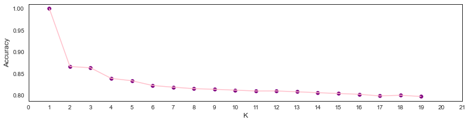

```python
from sklearn.neighbors import KNeighborsClassifier

#KNN LOOPING FOR n_neighbors value varitations
k_range = range(1,20)
accuracy = []
#Train Model and Predict
for k in k_range:
    neigh = KNeighborsClassifier(n_neighbors = k)
    neigh.fit(x_train_arr, y_train_arr)
    y_train_pred8 = neigh.predict(x_train_arr)
    y_test_pred8 = neigh.predict(x_test_arr)
    accuracy.append(metrics.accuracy_score(y_train_pred8, y_train_arr))

plt.figure(figsize=(13,3))
plt.xlabel('K')
plt.ylabel('Accuracy')
plt.scatter(k_range, accuracy, color='purple')
plt.plot(k_range, accuracy, color='pink')
plt.xticks(range(0,22));
```

```python
from sklearn.neighbors import KNeighborsClassifier
model3 = KNeighborsClassifier(n_neighbors=3)
model3.fit(x_train_arr, y_train_arr)
y_train_pred3 = model3.predict(x_train_arr)
y_test_pred3 = model3.predict(x_test_arr)

from sklearn.metrics import accuracy_score
print("Accuracy Score (Train):",accuracy_score(y_train_arr,y_train_pred3))
print("Confusion Matrix (Train) \n",confusion_matrix(y_train_arr,y_train_pred3))
```

```
Accuracy Score (Train): 0.8631082480156448
Confusion Matrix (Train)
 [[3717  598]
 [ 592 3786]]
```

Accuracy Score (Test) from Kaggle: 0.76057

## 4.4 Decision Trees

```python
from sklearn.tree import DecisionTreeClassifier
model4 = DecisionTreeClassifier()
model4 = model4.fit(x_train_arr,y_train_arr)
y_train_pred4 = model4.predict(x_train_arr)
y_test_pred4 = model4.predict(x_test_arr)

from sklearn.metrics import accuracy_score
print("Accuracy Score (Train):",accuracy_score(y_train_arr,y_train_pred4))
print("Confusion Matrix (Train) \n",confusion_matrix(y_train_arr,y_train_pred4))
```

```
Accuracy Score (Train): 0.9997699298285977
Confusion Matrix (Train)
 [[4315    0]
 [   2 4376]]
```

```python
Accuracy Score (Test) from Kaggle: 0.7386
```

## 4.5 SVM

```python
from sklearn import svm
model5 = svm.SVC(kernel='linear') # Linear Kernel
model5 = model5.fit(x_train_arr, y_train_arr)
y_train_pred5 = model5.predict(x_train_arr)
y_test_pred5 = model5.predict(x_test_arr)

from sklearn.metrics import accuracy_score
print("Accuracy Score (Train):",accuracy_score(y_train_arr,y_train_pred5))
print("Confusion Matrix (Train) \n",confusion_matrix(y_train_arr,y_train_pred5))
```

```
Accuracy Score (Train): 0.7936270562521569
Confusion Matrix (Train)
 [[3300 1015]
 [ 779 3599]]
```

## 4.6 Write Results

```python
y_test_pred1 = pd.DataFrame(y_test_pred1)

submission1 = data_val['PassengerId']
submission1 = pd.DataFrame(submission1)

submission1 = submission1.join(y_test_pred1, how='outer')
submission1 = submission1.rename(columns={0:'Transported'})
submission1['Transported'].replace(1, 'True', inplace=True)
submission1['Transported'].replace(0, 'False', inplace=True)
submission1.to_csv('submission1.csv', index = False)
submission1.head(5)
```

|  | PassengerId | Transported |
| --- | --- | --- |
| 0 | 0013_01 | True |
| 1 | 0018_01 | False |
| 2 | 0019_01 | True |
| 3 | 0021_01 | True |
| 4 | 0023_01 | True |

```python
y_test_pred2 = pd.DataFrame(y_test_pred2)

submission2 = data_val['PassengerId']
submission2 = pd.DataFrame(submission2)

submission2 = submission2.join(y_test_pred2, how='outer')
submission2 = submission2.rename(columns={0:'Transported'})
submission2['Transported'].replace(1, 'True', inplace=True)
submission2['Transported'].replace(0, 'False', inplace=True)
submission2.to_csv('submission2.csv', index = False)
submission2.head(5)
```

|  | PassengerId | Transported |
| --- | --- | --- |
| 0 | 0013_01 | False |
| 1 | 0018_01 | False |
| 2 | 0019_01 | True |
| 3 | 0021_01 | True |
| 4 | 0023_01 | True |

```python
y_test_pred3 = pd.DataFrame(y_test_pred3)

submission3 = data_val['PassengerId']
submission3 = pd.DataFrame(submission3)

submission3 = submission3.join(y_test_pred3, how='outer')
submission3 = submission3.rename(columns={0:'Transported'})
submission3['Transported'].replace(1, 'True', inplace=True)
submission3['Transported'].replace(0, 'False', inplace=True)
submission3.to_csv('submission3.csv', index = False)
submission3.head(5)
```

|  | PassengerId | Transported |
| --- | --- | --- |
| 0 | 0013_01 | True |
| 1 | 0018_01 | False |
| 2 | 0019_01 | True |
| 3 | 0021_01 | True |
| 4 | 0023_01 | False |

```python
y_test_pred4 = pd.DataFrame(y_test_pred4)

submission4 = data_val['PassengerId']
submission4 = pd.DataFrame(submission4)

submission4 = submission4.join(y_test_pred4, how='outer')
submission4 = submission4.rename(columns={0:'Transported'})
submission4['Transported'].replace(1, 'True', inplace=True)
submission4['Transported'].replace(0, 'False', inplace=True)
submission4.to_csv('submission4.csv', index = False)
submission4.head(5)
```

|  | PassengerId | Transported |
| --- | --- | --- |
| 0 | 0013_01 | False |
| 1 | 0018_01 | False |
| 2 | 0019_01 | True |
| 3 | 0021_01 | True |
| 4 | 0023_01 | True |

```python
y_test_pred5 = pd.DataFrame(y_test_pred5)

submission5 = data_val['PassengerId']
submission5 = pd.DataFrame(submission5)

submission5 = submission5.join(y_test_pred5, how='outer')
submission5 = submission5.rename(columns={0:'Transported'})
submission5['Transported'].replace(1, 'True', inplace=True)
submission5['Transported'].replace(0, 'False', inplace=True)
submission5.to_csv('submission5.csv', index = False)
submission5.head(5)
```

|  | PassengerId | Transported |
| --- | --- | --- |
| 0 | 0013_01 | True |
| 1 | 0018_01 | False |
| 2 | 0019_01 | False |
| 3 | 0021_01 | True |
| 4 | 0023_01 | False |